# 分布绘图

```python
import numpy as np
import pandas as pd
import matplotlib.pyplot as plt
import seaborn as sns
```

# 分布绘图

当我们上手一个数据集时，往往第一件事就是了解每个变量是如何分布的。这一部分会简单地演示如何在seaborn中检验一维分布和二维分布。

- distplot:一维分布
- jointplot：多维分布

## 1 一维分布：distplot

在seaborn中，查看单变量分布情况最方便的方法就是使用distplot()函数。默认情况下，它会画一个直方图，并且做一个核密度估计（KDE）曲线。

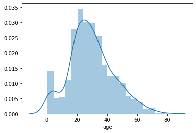

```python
# 导入titanic数据集,并绘制关于年龄的直方图
titanic = pd.read_csv("../data/titanic.csv")
sns.distplot(titanic['age'])
```

distplot有以下常用参数：

- kde（核密度曲线）：代表是否要显示kde曲线，默认是显示的。
- bins：代表直方图区间的数量，可以通过自己设置数目。
- rug：代表是否显示底部的胡须下线，下面的胡须线越密集，说明数据量越多
- 如果显示kde曲线（默认），那么y轴表示的是概率；也可以设置kde参数为False，那么y值代表的是数量。

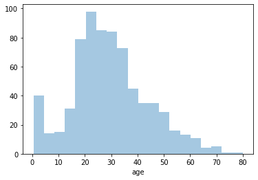

```python
# 关闭kde曲线
sns.distplot(titanic['age'],kde=False)
```

- 可以设置bins参数来控制直方图区间的数量。

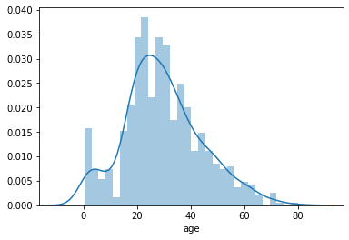

```python
# 设置直方图区间的数量为30
sns.distplot(titanic['age'],bins=30)
```

- 可以设置rug参数为True来显示底部的胡须。

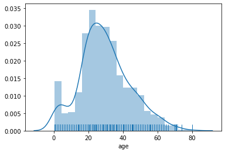

```python
# 设置rug参数来显示底部的胡须
sns.distplot(titanic['age'],rug=True)
```

## 2 二维分布：jointplot

将两个变量的联合分布形态可视化出来往往会很有用。在seaborn中，最简单的实现方式是使用jointplot()函数，它会生成多个面板，不仅展示了两个变量之间的关系，也在两个坐标轴上分别展示了每个变量的分布。

### 2.1 散点图

最常见的展示二元分布的方法是使用散点图，我们使用x、y两个坐标轴来定位每一个观测值。它类似于二维的地毯图。我么可以使用matplotlib中的plt.scatter()函数来绘制散点图，同时，jointplot()的默认绘制类型也是散点图。

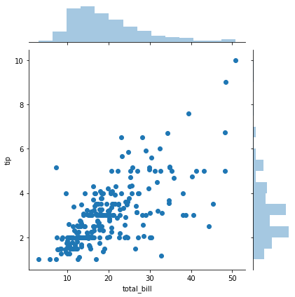

```python
# 导入tips数据集，并显示两个变量之间的关系
tips = pd.read_csv("../data/tips.csv")
sns.jointplot(x='total_bill',y='tip',data=tips)
```

### 2.2 六边形图

六边图（Hexbin），可以视为二维世界中的直方图，因为它展示了每个小六边形中观测点的数量。这种图在**大数据集**上表现最佳。我们使用matplotlib的plt.hexbin函数以及seaborn的jointplot(kind="hex")都可以绘制它。白色背景与六边图看起来更配哦：

- 现在有一份奥运会人员的数据，现在想要查看中国运动员身高和体重的分布情况：

```python
# 导入一份奥运会人员数据
athletes = pd.read_csv("../data/athlete_events.csv")
athletes
```

|  | ID | Name | Sex | Age | Height | Weight | Team | NOC | Games | Year | Season | City | Sport | Event | Medal |
| --- | --- | --- | --- | --- | --- | --- | --- | --- | --- | --- | --- | --- | --- | --- | --- |
| 0 | 1 | A Dijiang | M | 24.0 | 180.0 | 80.0 | China | CHN | 1992 Summer | 1992 | Summer | Barcelona | Basketball | Basketball Men's Basketball | NaN |
| 1 | 2 | A Lamusi | M | 23.0 | 170.0 | 60.0 | China | CHN | 2012 Summer | 2012 | Summer | London | Judo | Judo Men's Extra-Lightweight | NaN |
| 2 | 3 | Gunnar Nielsen Aaby | M | 24.0 | NaN | NaN | Denmark | DEN | 1920 Summer | 1920 | Summer | Antwerpen | Football | Football Men's Football | NaN |
| 3 | 4 | Edgar Lindenau Aabye | M | 34.0 | NaN | NaN | Denmark/Sweden | DEN | 1900 Summer | 1900 | Summer | Paris | Tug-Of-War | Tug-Of-War Men's Tug-Of-War | Gold |
| 4 | 5 | Christine Jacoba Aaftink | F | 21.0 | 185.0 | 82.0 | Netherlands | NED | 1988 Winter | 1988 | Winter | Calgary | Speed Skating | Speed Skating Women's 500 metres | NaN |
| ... | ... | ... | ... | ... | ... | ... | ... | ... | ... | ... | ... | ... | ... | ... | ... |
| 271111 | 135569 | Andrzej ya | M | 29.0 | 179.0 | 89.0 | Poland-1 | POL | 1976 Winter | 1976 | Winter | Innsbruck | Luge | Luge Mixed (Men)'s Doubles | NaN |
| 271112 | 135570 | Piotr ya | M | 27.0 | 176.0 | 59.0 | Poland | POL | 2014 Winter | 2014 | Winter | Sochi | Ski Jumping | Ski Jumping Men's Large Hill, Individual | NaN |
| 271113 | 135570 | Piotr ya | M | 27.0 | 176.0 | 59.0 | Poland | POL | 2014 Winter | 2014 | Winter | Sochi | Ski Jumping | Ski Jumping Men's Large Hill, Team | NaN |
| 271114 | 135571 | Tomasz Ireneusz ya | M | 30.0 | 185.0 | 96.0 | Poland | POL | 1998 Winter | 1998 | Winter | Nagano | Bobsleigh | Bobsleigh Men's Four | NaN |
| 271115 | 135571 | Tomasz Ireneusz ya | M | 34.0 | 185.0 | 96.0 | Poland | POL | 2002 Winter | 2002 | Winter | Salt Lake City | Bobsleigh | Bobsleigh Men's Four | NaN |

271116 rows × 15 columns

```python
# 筛选中国运动员
chinese_athletes = athletes[athletes['NOC']=='CHN']
chinese_athletes
```

|  | ID | Name | Sex | Age | Height | Weight | Team | NOC | Games | Year | Season | City | Sport | Event | Medal |
| --- | --- | --- | --- | --- | --- | --- | --- | --- | --- | --- | --- | --- | --- | --- | --- |
| 0 | 1 | A Dijiang | M | 24.0 | 180.0 | 80.0 | China | CHN | 1992 Summer | 1992 | Summer | Barcelona | Basketball | Basketball Men's Basketball | NaN |
| 1 | 2 | A Lamusi | M | 23.0 | 170.0 | 60.0 | China | CHN | 2012 Summer | 2012 | Summer | London | Judo | Judo Men's Extra-Lightweight | NaN |
| 1072 | 602 | Abudoureheman | M | 22.0 | 182.0 | 75.0 | China | CHN | 2000 Summer | 2000 | Summer | Sydney | Boxing | Boxing Men's Middleweight | NaN |
| 2611 | 1463 | Ai Linuer | M | 25.0 | 160.0 | 62.0 | China | CHN | 2004 Summer | 2004 | Summer | Athina | Wrestling | Wrestling Men's Lightweight, Greco-Roman | NaN |
| 2612 | 1464 | Ai Yanhan | F | 14.0 | 168.0 | 54.0 | China | CHN | 2016 Summer | 2016 | Summer | Rio de Janeiro | Swimming | Swimming Women's 200 metres Freestyle | NaN |
| ... | ... | ... | ... | ... | ... | ... | ... | ... | ... | ... | ... | ... | ... | ... | ... |
| 270443 | 135272 | Zou Wenzhi | M | NaN | NaN | NaN | China | CHN | 1948 Summer | 1948 | Summer | London | Football | Football Men's Football | NaN |
| 270444 | 135273 | Zou Yuchen | M | 20.0 | 203.0 | 107.0 | China | CHN | 2016 Summer | 2016 | Summer | Rio de Janeiro | Basketball | Basketball Men's Basketball | NaN |
| 270445 | 135274 | Zou Zhenxian | M | 28.0 | 184.0 | 72.0 | China | CHN | 1984 Summer | 1984 | Summer | Los Angeles | Athletics | Athletics Men's Triple Jump | NaN |
| 270559 | 135318 | Zu Lijun | M | 26.0 | 188.0 | 87.0 | China | CHN | 2016 Summer | 2016 | Summer | Rio de Janeiro | Swimming | Swimming Men's 10 kilometres Open Water | NaN |
| 270822 | 135445 | Zuo Yue | M | 21.0 | 192.0 | 88.0 | China | CHN | 1984 Summer | 1984 | Summer | Los Angeles | Volleyball | Volleyball Men's Volleyball | NaN |

5141 rows × 15 columns

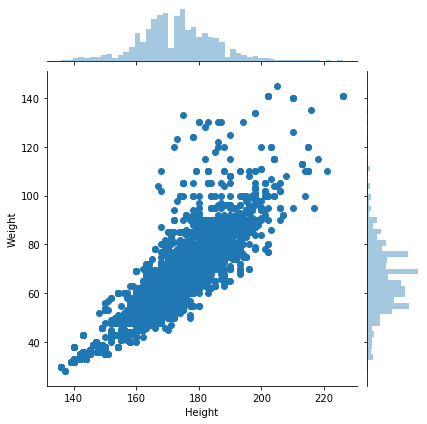

```python
# 使用散点图查看身高和体重的分布情况
sns.jointplot(x="Height",y="Weight",data=chinese_athletes)
```

针对这种数据量比较大的情况，可以采用六边形图来绘制，也就是将之前的散点变成六边形，六边形有一个区间大小，之前这些点落在这个六边形中越多颜色越深。示例代码如下：

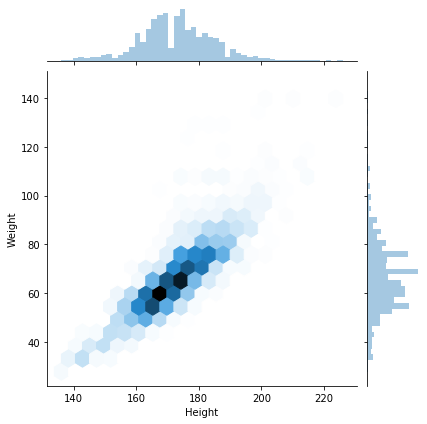

```python
# 使用六边形图对身高和体重的分布进行绘制
sns.jointplot(x="Height",y="Weight",data=chinese_athletes,
              kind="hex",gridsize=20)
```

## 3 成对绘图：pairplot

成对关系的可视化是指在一个数据集的所有变量中，两两之间的关系。假如我们想要看多个变量中两两组合之间的联合分布情况，我们可以使用pairplot()函数，它会创建一个由多个坐标轴构成的矩阵，然后把两两之间（一般是DataFrame的列之间的组合）的关系分别绘制在不同的坐标轴上去。默认情况下，它还会将每个变量自己的分布情况画在对角线的位置：

```python
# 导入iris鸢尾花数据集
iris = pd.read_csv("../data/iris.csv")
iris
```

|  | sepal_length | sepal_width | petal_length | petal_width | species |
| --- | --- | --- | --- | --- | --- |
| 0 | 5.1 | 3.5 | 1.4 | 0.2 | setosa |
| 1 | 4.9 | 3.0 | 1.4 | 0.2 | setosa |
| 2 | 4.7 | 3.2 | 1.3 | 0.2 | setosa |
| 3 | 4.6 | 3.1 | 1.5 | 0.2 | setosa |
| 4 | 5.0 | 3.6 | 1.4 | 0.2 | setosa |
| ... | ... | ... | ... | ... | ... |
| 145 | 6.7 | 3.0 | 5.2 | 2.3 | virginica |
| 146 | 6.3 | 2.5 | 5.0 | 1.9 | virginica |
| 147 | 6.5 | 3.0 | 5.2 | 2.0 | virginica |
| 148 | 6.2 | 3.4 | 5.4 | 2.3 | virginica |
| 149 | 5.9 | 3.0 | 5.1 | 1.8 | virginica |

150 rows × 5 columns

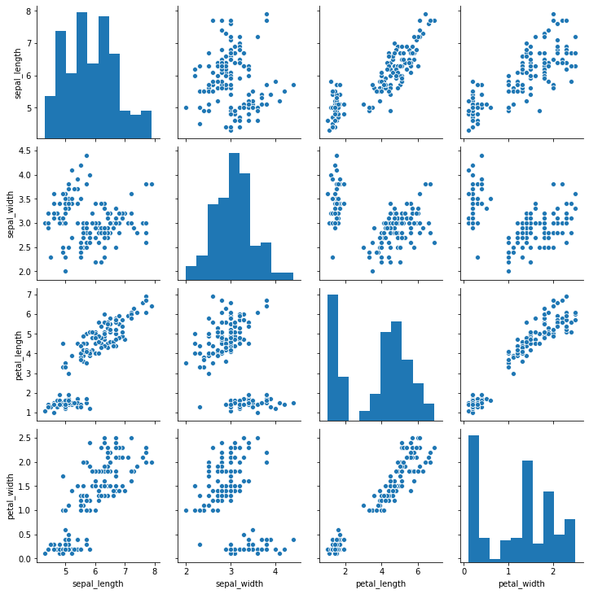

```python
# 对iris数据集的变量进行两两组合展示分布关系
sns.pairplot(iris)
```

默认情况下，对角线的图（x和y轴的列相同）是直方图，其他地方的图是散点图，如果想要修改这两种图，可以通过diag_kind和kind来实现。其中这两个参数可取的值为：

- diag_kind:auto，hist，kde
- kind：scatter，reg

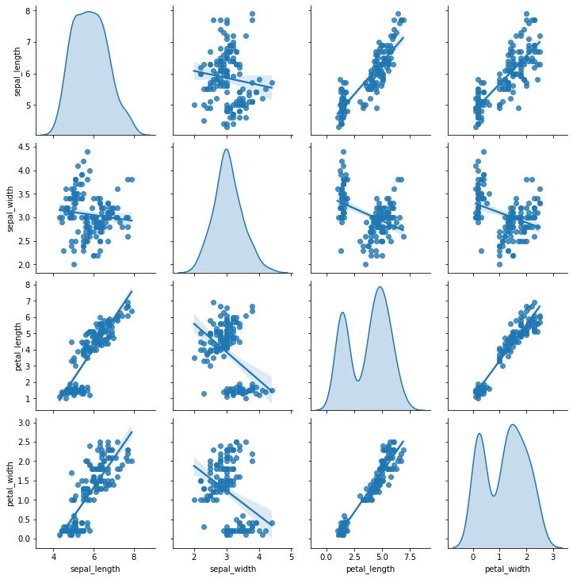

```python
# 修改默认的图像
sns.pairplot(iris,diag_kind="kde",kind="reg")
```